# Neuroimaging in R

February 19, 2015

## Introduction: Packages

- oro.nifti: read/write data, the nifti object
- fslr: process data (need FSL for most of the fun)
- ANTsR: process data (need cmake)
- extrantsr: makes ANTsR easier (need ANTsR)

## Install these packages

```r
install.packages("oro.nifti")
install.packages("devtools")
devtools::install_github("stnava/ANTsR") # takes long
devtools::install_github("muschellij2/extrantsr")
devtools::install_github("muschellij2/fslr")
```

## Files

Multi-modal dataset from SuBLIME (thanks Elizabeth), raw and unprocessed (other than NIfTI conversion).

- 4 modalities: T1, T2, PD, FLAIR
- 2 time points Baseline and Followup

```r
files
                   base_t1                    base_t2
   "01-Baseline_T1.nii.gz"    "01-Baseline_T2.nii.gz"
                   base_pd                 base_flair
   "01-Baseline_PD.nii.gz" "01-Baseline_FLAIR.nii.gz"
                      f_t1                       f_t2
   "01-Followup_T1.nii.gz"    "01-Followup_T2.nii.gz"
                      f_pd                    f_flair
   "01-Followup_PD.nii.gz" "01-Followup_FLAIR.nii.gz"
```

## Read in the Files!

Let's read in the baseline T1. The `readNIfTI` function is the workhorse:

```r
library(oro.nifti)
base_t1 = readNIfTI(files["base_t1"])
```

```r
base_t2 = readNIfTI(files["base_t2"])
Error in if (sum(T != 0) == 3 && det(T) != 0) {: missing value where TRUE/FALSE needed
```

```r
base_t2 = readNIfTI(files["base_t2"], reorient = FALSE)
```

## An aside on `reorient` in `readNIfTI`

Arguments for `readNIfTI`:

```r
args(readNIfTI)
function (fname, verbose = FALSE, warn = -1, reorient = TRUE,
    call = NULL)
NULL
```

The default is `reorient = TRUE` but this fails **a lot**, especially when the transformation matrix is not diagonal.

Use `reorient=FALSE`

## Quick Plots

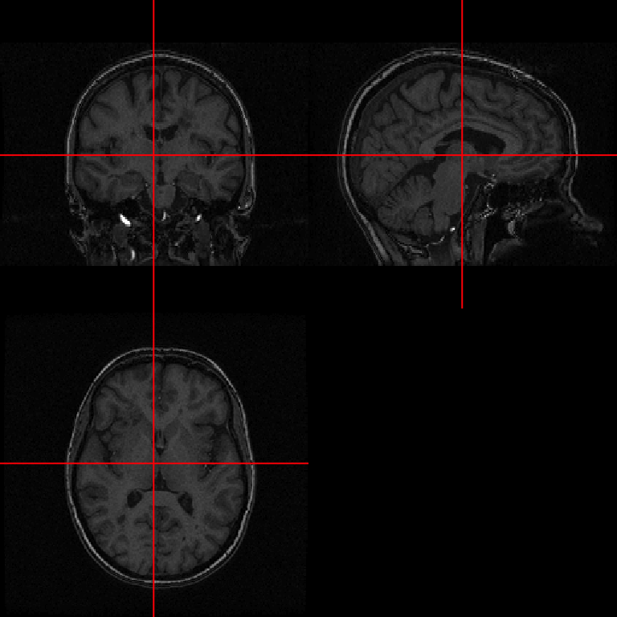

```r
orthographic(base_t1)
```

## Quick Plots

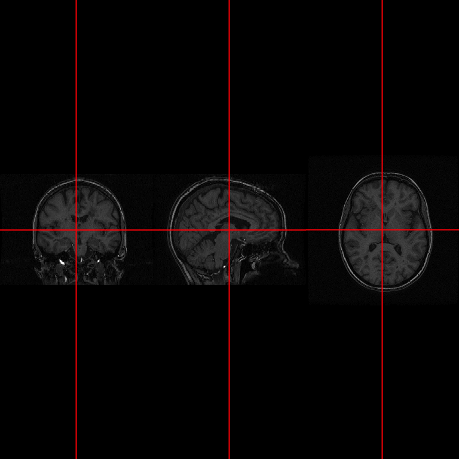

```r
library(fslr)
fslr::ortho2(base_t1, mfrow= c(1, 3), add.orient = FALSE)
```

## Creating new nifti objects

''One image'' operations return `nifti` objects:

```r
arr = base_t1 >= 40
class(arr)
[1] "nifti"
attr(,"package")
[1] "oro.nifti"
```

## Creating new nifti objects: Copy and Replace

''Two image'' operations return `array`. Copy `nifti` object, replace data:

```r
arr = base_t1 >= 40 & base_t1 < 60
class(arr)
[1] "array"
```

```r
mask = base_t1
mask@.Data = arr
class(mask)
[1] "nifti"
attr(,"package")
[1] "oro.nifti"
```

## Creating new nifti objects: Copy and Replace

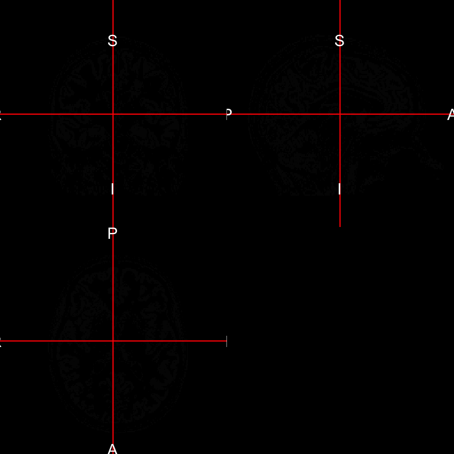

```r
ortho2(mask)
```

## Creating new nifti objects: Copy and Replace

Must reset the `cal_min` and `cal_max` values, use the `fslr` function `cal_img`:

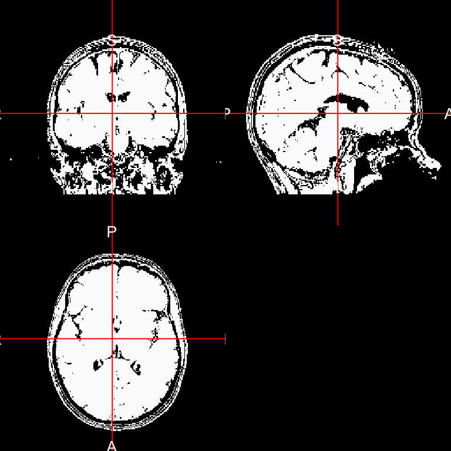

```r
mask = cal_img(mask)
ortho2(mask)
```

## Use `cal_img` with `writeNIfTI`

`cal_img` is also useful for writing `nifti` objects.

If the range of the data isn't `c(cal_min, cal_max)`, then the `writeNIfTI` errors:

```r
mask@.Data[5] = 3
writeNIfTI(mask, filename = tempfile())
Error in .writeNIfTI(nim, filename, onefile, gzipped, verbose, warn): range(img) != c(cal_min,cal_max)
```

## Creating new nifti objects: `niftiarr`

Use `niftiarr` to create new `nifti` objects from old one:

```r
mask = niftiarr(base_t1, base_t1 >= 40 & base_t1 < 60)
class(mask)
[1] "nifti"
attr(,"package")
[1] "oro.nifti"
```

## Creating new nifti objects: `niftiarr`

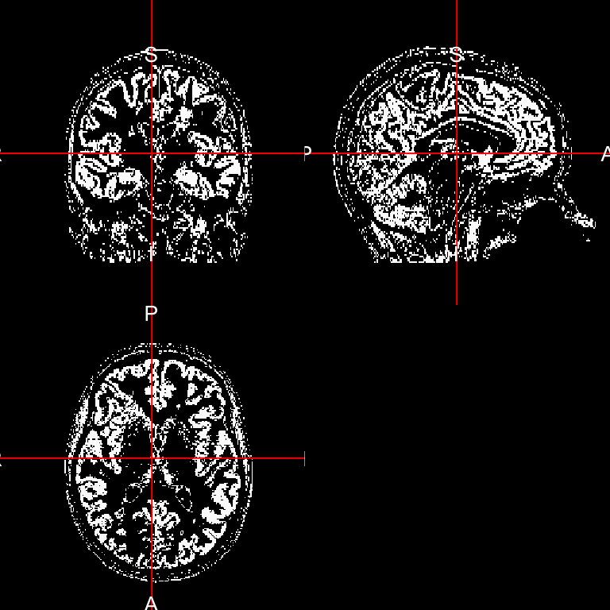

```r
ortho2(mask)
```

## Skull Stripping

Using FSL BET for the baseline T1 image:

```r
library(fslr)
ss_t1 = fslbet(base_t1, retimg = TRUE, opts = "-f 0.1 -v",
               betcmd = "bet2", outfile = "SS_Image")
Warning in get.fsloutput(): Can't find FSLOUTPUTTYPE, setting to NIFTI_GZ
FSLDIR=/usr/local/fsl/; export FSLDIR; sh ${FSLDIR}/etc/fslconf/fsl.sh; FSLOUTPUTTYPE=NIFTI_GZ; export FSLOUTPUTTYPE; $FSLDIR/bin/bet2 "/var/folders/1s/wrtqcpxn685_zk570bnx9_rr0000gr/T//RtmpZDPO83/file846d5eaae1dd.nii.gz" "SS_Image" -f 0.1 -v
```

```r
fslbin(file = "SS_Image", outfile = "Brain_Mask")
FSLDIR=/usr/local/fsl/; export FSLDIR; sh ${FSLDIR}/etc/fslconf/fsl.sh; FSLOUTPUTTYPE=NIFTI_GZ; export FSLOUTPUTTYPE; $FSLDIR/bin/fslmaths "SS_Image"  -bin   "Brain_Mask";
character(0)
```

- `fslbet` - the command
- `retimg` - Return an image
- `opts` - options of bash `bet` command
- `betcmd` - can use `bet2` or `bet` (wrapper for `bet2`)

## Overlaying

`orthographic` allows for overlays, but must set voxels to `NA` we don't wish to see (*NOT ZERO*):

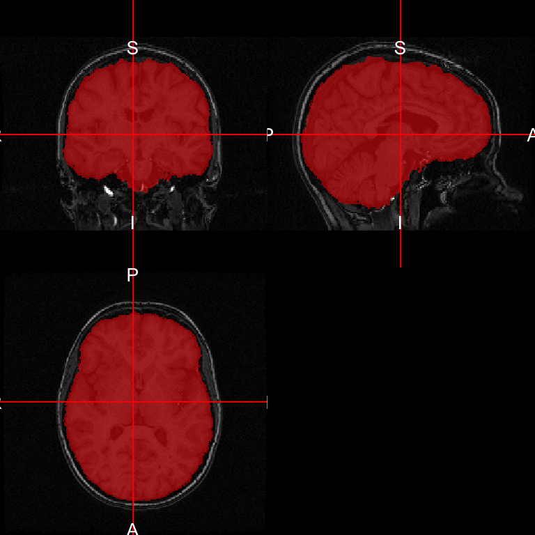

```r
library(scales)
mask = cal_img(ss_t1 > 0)
mask[mask == 0] = NA
ortho2(base_t1, y=mask, col.y=alpha("red", 0.5))
```

## Bias Field Correction

`bias_correct` from `extrantsr` package:

```r
library(ANTsR)
library(extrantsr)
n3_t1 = bias_correct(file = base_t1, correction = "N3", retimg=TRUE)
n4_t1 = bias_correct(file = base_t1, correction = "N4", retimg=TRUE)
```

## Registration

`extrantsr::ants_regwrite` will take in a file and a template, registre the file to the template, and can perform the reverse operation on another image.

```r
reg_base_t2 = ants_regwrite(filename = files["base_t2"],
                            template.file = files['base_t1'],
                            retimg= TRUE,
                            typeofTransform = "Rigid",
                            remove.warp = TRUE)
```

## Preprocess MRI: within a visit

`extrantsr::preprocess_mri_within` will do N3/N4 Correction, skull strip (or mask), and register to the first scan.

```r
proc_images = preprocess_mri_within(
  files = files[c("base_t1", "base_t2", "base_pd", "base_flair")],
    retimg = TRUE, maskfile = "Brain_Mask.nii.gz")
```

## Preprocess MRI: across visits

`preprocess_mri_across` combines `preprocess_mri_within` and `ants_regwrite`

```r
outfiles = gsub("[.]nii", '_process.nii', files)
preprocess_mri_across(
  baseline_files = files[c("base_t1", "base_t2", "base_pd", "base_flair")],
    followup_files = files[c("f_t1", "f_t2", "f_pd", "f_flair")],
    baseline_outfiles = outfiles[c("base_t1", "base_t2", "base_pd", "base_flair")],
    followup_outfiles = outfiles[c("f_t1", "f_t2", "f_pd", "f_flair")],
  maskfile = "Brain_Mask.nii.gz")
```

## Other useful functions from fslr

- `window_img` - set min and max values of image (good for plotting)
- `drop_img_dim` - drop dimension if is dimension is 1
- `mask_img` - mask image with an array/nifti object
- `robust_window` - quantile the image then use `window_img` (take out large values)
- `fslhd` and `fslval` can get information from an image without having to read it in
- `checkimg` - checks if an image is character, writes `nifti` to tempfile, returns character
- `check_nifti` - checks if an image is `nifti`, reads filename, returns `nifti`

## Overview

1. `oro.nifti` - reading/writing nifti objects
2. `ANTsR`
   - bias field corrrection
   - registration: linear, non-linear (symmetric)
3. `fslr`
   - can perform image operations from FSL
   - has helper functions for `nifti` objects
4. extrantsr - helper functions for ANTsR
   - wrapper functions for preprocessing

## Bonus: Cutting Image function

```r
cut_img = function(img, breaks, cols, include.lowest = TRUE, plot.image=TRUE, ...){
  cuts = cut(x=c(img), breaks=breaks, include.lowest = include.lowest)
  cut_img = niftiarr(img, as.numeric(cuts))
  ybreaks= sort(unique(as.numeric(cuts)))
  ybreaks = c(0, ybreaks[!is.na(ybreaks)])
  lab = levels(cuts)
  if (plot.image){
    ortho2(img, cut_img, ybreaks = ybreaks, col.y = cols,
         legend = lab,
         leg.col = cols,
         ... )
  }
  return(list(cut_img = cut_img, ybreaks= ybreaks, legend = lab, cols= cols))
}
```

## Bonus: Cutting Image function

Creating the quantiles of the skull-stripped image:

```r
img = robust_window(ss_t1)
q = quantile(c(img[img > 0]), prob = seq(0, 1, by=0.25))
breaks = unique(q)
cols = alpha(c("blue", "yellow", "orange", "red"), 0.5)
```

## Bonus: Cutting Image function

```r
cimg = cut_img(ss_t1, breaks= breaks, cols = cols)
```

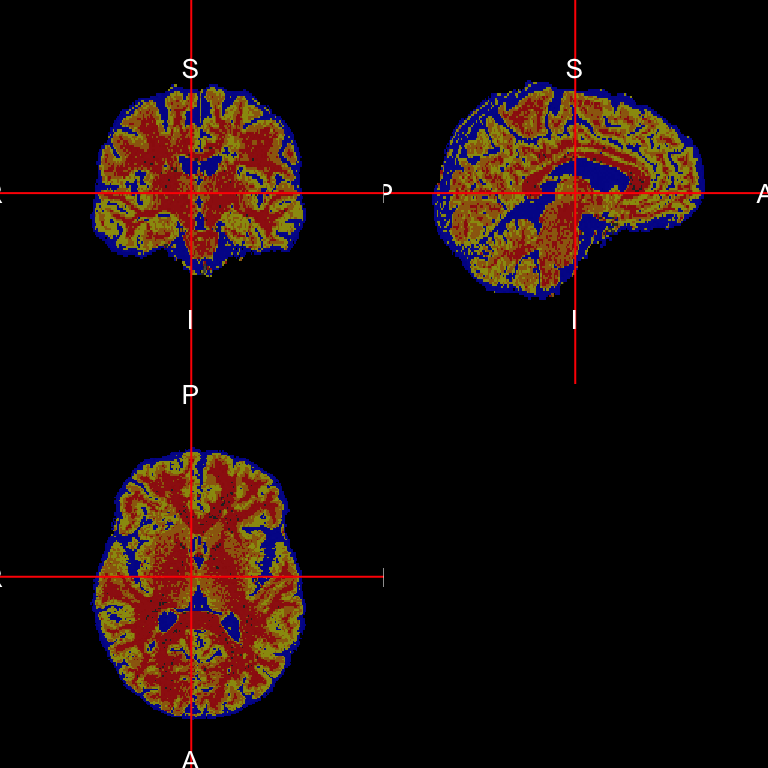

## Dropping out top quantile:

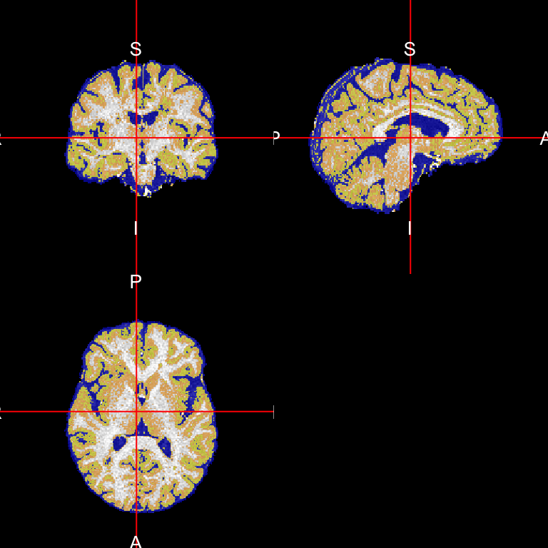

```r
cimg2 = cimg$cut_img
cimg2[ cimg2 == 4] = NA
cimg2 = cal_img(cimg2)
ortho2(img, cimg2, ybreaks = cimg$ybreaks, col.y = cimg$cols,
       legend = cimg$legend,
       leg.col = cimg$cols)
```

## Dropping out lower quantile:

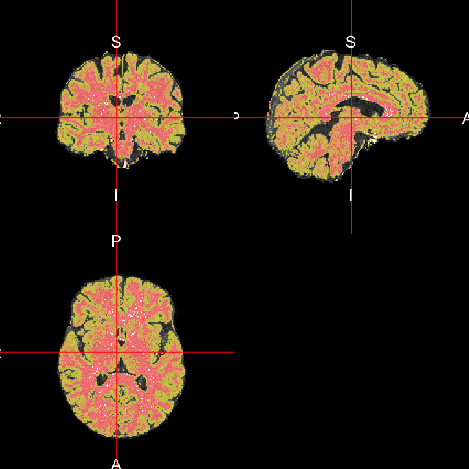

```r
cimg2 = cimg$cut_img
cimg2[ cimg2 == 1] = NA
cimg2 = cal_img(cimg2)
ortho2(img, cimg2, ybreaks = cimg$ybreaks, col.y = cimg$cols,
       legend = cimg$legend,
       leg.col = cimg$cols)
```